# US Media_Apr22

First we install the relevant libraries.

Then we load them

We load the data that has been pre-processed in Python. Words with a frequency less than 3 were also removed from the corpus.

```r
# set working directory
datadir <- "C:/Users/analo/OneDrive - University of Glasgow/University of Glasgow/Amsterdam Visit/Voter-ID-US-News-Media/Descriptives/"
df <- readtext(paste0("preprocessed.csv"), text_field = "title")
```

Then we create the corpus

```r
corpus <- corpus(df)
```

We create a tokens object. tokens() segments texts in a corpus into tokens (words or sentences) by word boundaries. By default, tokens() only removes separators (typically whitespaces).

```r
tokens <- tokens(corpus, remove_punct = TRUE, remove_symbols = TRUE, remove_numbers = TRUE)%>%
  tokens_compound(pattern = phrase(c('U S', 'united_states')))%>%
  tokens_select(pattern = c("advertisement", "u"), selection = "remove")%>%
  tokens_replace(c("id"), c("identification"))%>%
  tokens_replace(c("U_S"), c("united_states"))%>%
  tokens_group(groups = ideology) %>%
  tokens()

tokens <- tokens_select(tokens, pattern = stopwords("en"), selection = "remove")
```

```r
dfm <- dfm(tokens)
```

#### Top words

We plot top features:

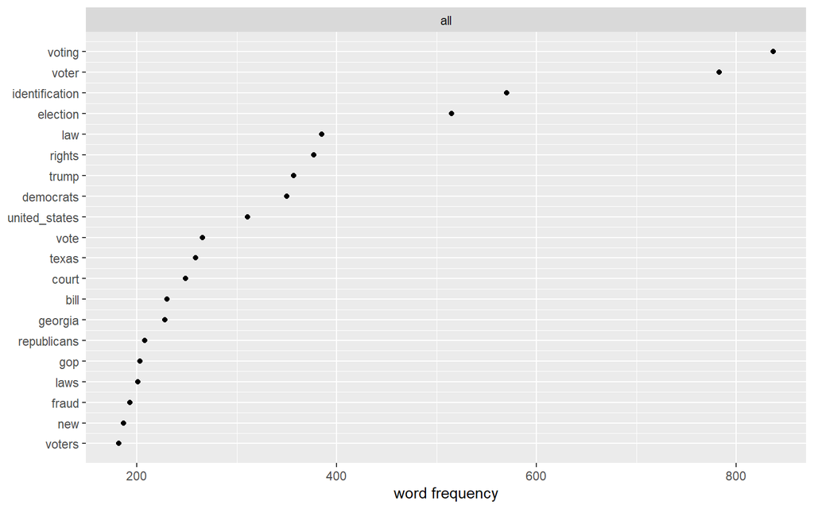

```r
freq <- textstat_frequency(dfm, n = 20)
ggplot(data = freq, aes(x = nrow(freq):1, y = frequency)) +
geom_point() +
facet_wrap(~ group, scales = "free") +
coord_flip() +
scale_x_continuous(breaks = nrow(freq):1,
labels = freq$feature) +
labs(x = NULL, y = "word frequency")
```